# Basic Package Usage

Welcome to `rcade`! This is a package that allows you to make and play live-input games in vanilla R.

This article describes how to use the package to play games; see `vignette("rcade")` for an overview of the package itself, or `vignette("engine")` for info on how the games run.

## 1. How to Play a Game

To play a game, you’ll need two RStudio[^1] sessions open in separate windows.

One of them, which I’ll call the **display session**, will display the game’s graphics; it should be a relatively large window, and you’ll want to zoom out with `cmd -` or equivalent.

The second sessions is the **input session** and will be where you’ll interact with the game once it starts.

**Example: [click to expand]**

An example of a good setup: the display session console is large and zoomed out, with the input session accessible.

[figure not shown]

Once you have those two windows open, follow these steps:

1. **Both sessions** need to load the package with `library(rcade)`.
2. In the **display session**, start the game you want to play. I recommend `Snake`:

```
quickload(Snake)
```

3. Press Enter to skip the dialog and play the game with default settings.
4. Then, go to the **input session** and run

```
inputs.listen()
```

5. You should now be able to enter text in the input session to control the game! Snake uses WASD.

Because of how R works, you have to **press Enter** every time you want to send an input. So to turn to the right, you’d have to press `D-ENTER` in succession.

**Demonstration:**

Here’s a demonstration of this process in action. The functions at the start are equivalent to running `quickload()`, and then I drag over the input session and send input with it.

[figure not shown]

## 2. Prebuilt Games

Below are the ROMs (games) I’ve made to be included in the package. To run one, follow the steps above with the desired ROM in `quickload()`.

You can find more info on these in `vignette(rcade)`.

### Snake

```
quickload(Snake)
```

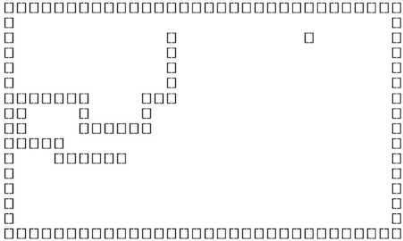

Classic Snake game controlled with WASD. When you load the ROM, you’ll be prompted if you want to use the default settings or change the speed and boundaries of the game.

### Bad Apple

```
quickload(BadApple)
```

[figure not shown]

This one isn’t a game, just a tech demo for the graphics engine. Running this will render a video to the console, no input session needed.

### R<sup>2</sup>Studio

```
quickload(R2Studio)
```

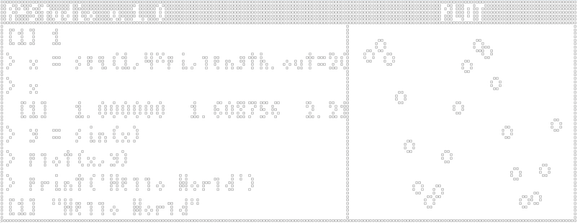

Pronounced “r-squared studio”— it’s a pun on the Pearson r<sup>2</sup>, and the fact that it’s RStudio in RStudio! Renders a mini console and UI, which you can run commands in like a regular R session. Basic scatterplotting is supported.

## 3. Making Games

You can make your own game with `rom.init()`; `vignette("Snake")` is a full devlog of the process of making the Snake ROM from start to finish. Once you’ve made a ROM, you can run it just like the games above!

The other game articles (see `vignette(rcade)`) go into more detail about game logic and technical implementations and may be useful for advanced game development.

[^1]: This package only works in RStudio, since regular R doesn’t support console wiping with `cat('\f')`. Though I may have found a workaround…